# ECO 602 - Analysis of Environmental Data

## ‘qbinom()’

*qbinom(p, size, prob, lower.tail)*

Similar to normal distribution functions, the *‘qbinom()’* function gives the quantile. Also, this quantile function is the opposite of *‘pbinom()’*. It provides the number of successful trials less than or equal to a probability *p* of a positive outcomes, the *size* of the total number of trials, and the probability of a positive trial *prob*. The *lower.tail* variable in the command is logical. When *TRUE* (which is default), it implies probability of less than or equal to x (or *p*), and when *FALSE*, it implies greater than or equal to x (or *p*).

- The *‘qbinom()’* function example is shown below. Referring to the previous example, as this function is the inverse of *‘pbinom()’*, we will ask for the bottom 20% of outcomes with the 95% success rate and 400 patients, and also with the 60% success rate and 400 patients who responded positively to this vaccine.

```r
qbinom(.20, 400, .95) # Result was 376 persons. This was very close to our visual estimate of the plotted graph.
```

```
## [1] 376
```

```r
qbinom(.20, 400, .6) # Result was 232 persons. This was also very close to our visual estimate of the plotted graph.
```

```
## [1] 232
```

```r
#These results state that in 20% of the trials, the above number results of people will have a positive response to the vaccine given its clinical success rates of 95% and 60%.
```

- If we wanted to calculate the bottom quantile of 99.9% of outcomes for the same success rates and numberof patients, we would run the following script:

```r
qbinom(.999, 400, .95) # Result was 392 persons. This was very also close to our visual estimate of the plotted graph.
```

```
## [1] 392
```

```r
qbinom(.999, 400, .6) # Result was 270 persons. This was also very close to our visual estimate of the plotted graph.
```

```
## [1] 270
```

# Functions 5: Other Functions

## ‘subset()’

The *‘subset()’* function is used as an indexing feature for accessing object elements. It can be used to select and filter variables and observations. This is particularly useful for large data sets. This function selects specified rows and columns from a data frame, and creates a vector of these values that can be used in subsequent scripts for a narrower data set analysis.

- An example of the *‘subset()’* function is shown below, using the existing data of the *palmerpenguins* data set.

```r
summary(penguins) # Summary of the "palmerpenguins' data set.
```

```
##       species          island    bill_length_mm  bill_depth_mm
##  Adelie   :152   Biscoe   :168   Min.   :32.10   Min.   :13.10
##  Chinstrap: 68   Dream    :124   1st Qu.:39.23   1st Qu.:15.60
##  Gentoo   :124   Torgersen: 52   Median :44.45   Median :17.30
##                                  Mean   :43.92   Mean   :17.15
##                                  3rd Qu.:48.50   3rd Qu.:18.70
##                                  Max.   :59.60   Max.   :21.50
##                                  NA's   :2       NA's   :2
##  flipper_length_mm  body_mass_g       sex           year
##  Min.   :172.0     Min.   :2700   female:165   Min.   :2007
##  1st Qu.:190.0     1st Qu.:3550   male  :168   1st Qu.:2007
##  Median :197.0     Median :4050   NA's  : 11   Median :2008
##  Mean   :200.9     Mean   :4202                Mean   :2008
##  3rd Qu.:213.0     3rd Qu.:4750                3rd Qu.:2009
##  Max.   :231.0     Max.   :6300                Max.   :2009
##  NA's   :2         NA's   :2
```

```r
subset(penguins, species == "Chinstrap") #Subset of the Chinstrap species
```

```
## # A tibble: 68 x 8
##    species island bill_length_mm bill_depth_mm flipper_length_~ body_mass_g
##    <fct>   <fct>           <dbl>         <dbl>            <int>       <int>
##  1 Chinst~ Dream            46.5          17.9              192        3500
##  2 Chinst~ Dream            50            19.5              196        3900
##  3 Chinst~ Dream            51.3          19.2              193        3650
##  4 Chinst~ Dream            45.4          18.7              188        3525
##  5 Chinst~ Dream            52.7          19.8              197        3725
##  6 Chinst~ Dream            45.2          17.8              198        3950
##  7 Chinst~ Dream            46.1          18.2              178        3250
##  8 Chinst~ Dream            51.3          18.2              197        3750
##  9 Chinst~ Dream            46            18.9              195        4150
## 10 Chinst~ Dream            51.3          19.9              198        3700
## # ... with 58 more rows, and 2 more variables: sex <fct>, year <int>
```

```r
chinstrap <- subset(penguins, species == "Chinstrap") #Subset of the Chinstrap species placed in vector

subset(chinstrap, sex == "female") # Subset of the Chinstrap species female sex
```

```
## # A tibble: 34 x 8
##    species island bill_length_mm bill_depth_mm flipper_length_~ body_mass_g
##    <fct>   <fct>           <dbl>         <dbl>            <int>       <int>
##  1 Chinst~ Dream            46.5          17.9              192        3500
##  2 Chinst~ Dream            45.4          18.7              188        3525
##  3 Chinst~ Dream            45.2          17.8              198        3950
##  4 Chinst~ Dream            46.1          18.2              178        3250
##  5 Chinst~ Dream            46            18.9              195        4150
##  6 Chinst~ Dream            46.6          17.8              193        3800
##  7 Chinst~ Dream            47            17.3              185        3700
##  8 Chinst~ Dream            45.9          17.1              190        3575
##  9 Chinst~ Dream            58            17.8              181        3700
## 10 Chinst~ Dream            46.4          18.6              190        3450
## # ... with 24 more rows, and 2 more variables: sex <fct>, year <int>
```

```r
female_chinstrap <- subset(chinstrap, sex == "female") # Subset of the Chinstrap species female sex placed in a vector
```

## ‘libary() and require()’

R packages are a collection of R functions, which include complied code and sample data, and are stored under a directory called *library* in the R environment. By default, R installs a set of packages during installation.

Running the *‘library()’* function empty lists all the available packages, installed by default. Running this function with a specified package will promt and error message if it is not available or load into project if it is available. Similarly, running the *‘require()’* function for a particular package, loads that specified package into a project in R. The main difference is the phrasing of the error code in case the requested package is not installed, and that the library function by itself opens a new window in R with a full list of all available data sets to choose from.

-An example of these two functions using the *palmerpenguins* data set is shown below:

```r
library() # This script opens a new window in R studio listing all the available packages. This is useful for a preview of all available data set titles and brief descriptions. We can see that palmerpenguins is available.

library(palmerpenguins)# This script, with the direct input of the data set we are interested in, will output an error message if this data set is not installed.

library(xyz) # In this example, as the data set "xyz" does not exist, an error message is displayed.
```

```
## Error in library(xyz): there is no package called 'xyz'
```

```r
require(palmerpenguins) # This script loads this available data set into the project.

require(xyz) # In this example, as the data set "xyz" does not exist, an error message is displayed.
```

## ‘read.csv()’

The *‘read.csv()’* function tells R where to locate the data file for analysis. There are two ways to get to a file in R, first using a relative path and second using an absolute path.

- An example of how to use the *‘read.csv()’* function is explained in the example below:

```r
require("here") # Loading this script from R package library which will help set the origin directory

here("data", "hab.sta.csv") # This function helps locate the "data" folder directory when it cannot be found and is set someplace outside of the R project directory. The output will provide the absolute path to the file.
```

```
## [1] "C:/Users/avery/Documents/GitHub/Eco_602_2020/data/hab.sta.csv"
```

```r
file.exists(here("data", "hab.sta.csv")) # This scripts verifies the location of the data file and its directory. The output is TRUE in this case.
```

```
## [1] TRUE
```

```r
read.csv(here("data", "hab.sta.csv")) # This script embeds the here command into the read.csv command, it tells R where the data file and its directory are and to read the data file in a single step script.
```

[output not shown]

[output cut: 3126 more lines]

```r
dat_habitat<- read.csv(here("data", "hab.sta.csv")) # This script creates a data frame of the imported data file
```

# Part 2: Data Anaylsis

## Numerical Exploration

```r
delomys= read.csv("https://michaelfrancenelson.github.io/eco_602_634_2020/data/delomys.csv")
summary(delomys$body_mass)
```

```
##    Min. 1st Qu.  Median    Mean 3rd Qu.    Max.
##    5.00   35.00   43.00   44.06   54.00  105.00
```

```r
summary(delomys$body_length)
```

```
##    Min. 1st Qu.  Median    Mean 3rd Qu.    Max.
##    49.0   106.0   116.0   114.7   124.0   265.0
```

```r
shapiro.test(delomys$body_mass)
```

```
##
##  Shapiro-Wilk normality test
##
## data:  delomys$body_mass
## W = 0.99506, p-value = 4.33e-05
```

```r
shapiro.test(delomys$body_length)
```

```
##
##  Shapiro-Wilk normality test
##
## data:  delomys$body_length
## W = 0.87609, p-value < 2.2e-16
```

## Graphical Exploration

### Scatterplot

Body Mass and Body Length

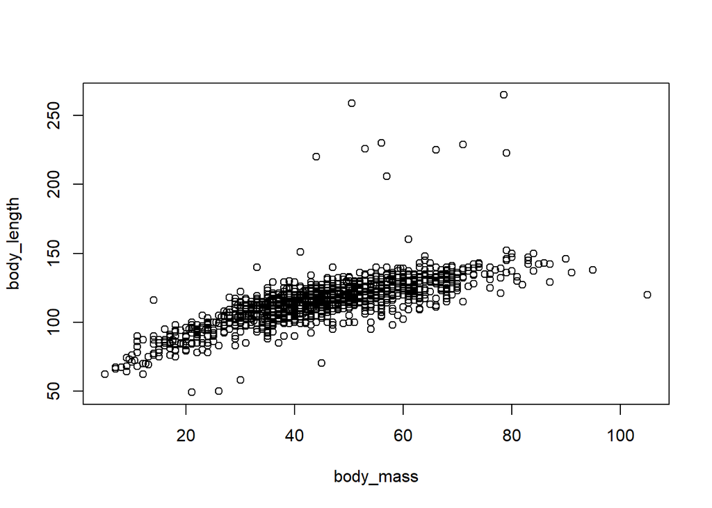

```r
plot(body_length~body_mass, data = delomys)
```

### Histogram

Body Length

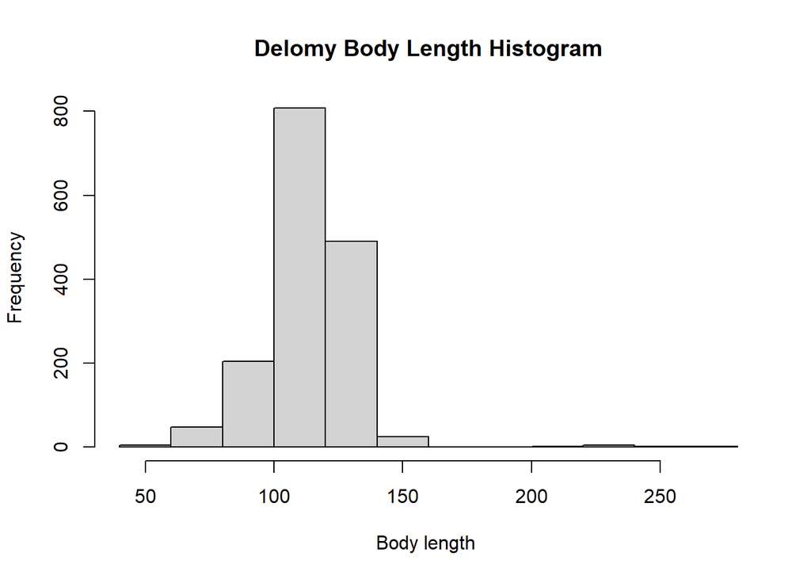

```r
hist(delomys$body_length, main = "Delomy Body Length Histogram",
     xlab = "Body length ",
     ylab = "Frequency")
```

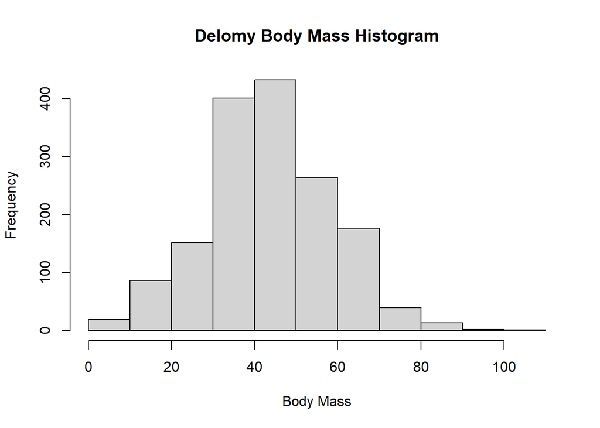

```r
hist(delomys$body_mass, main = "Delomy Body Mass Histogram",
     xlab = "Body Mass",
     ylab = "Frequency",
     )
```

### Conditional Boxplot

Body mass, conditioned on species (column binomial)

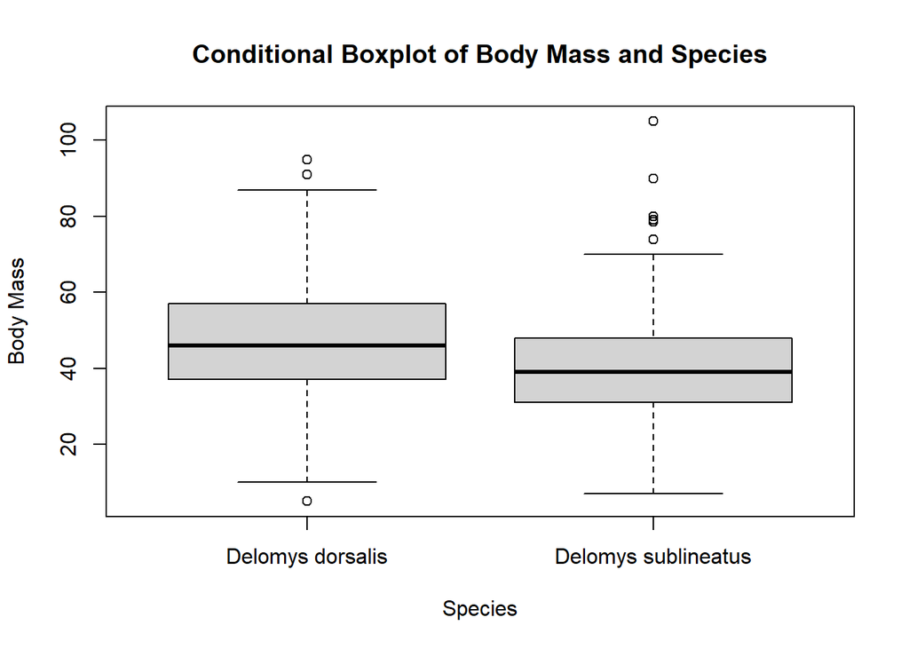

```r
boxplot(body_mass~binomial, data=delomys,
        main = "Conditional Boxplot of Body Mass and Species",
        xlab = "Species",
        ylab = "Body Mass")
```

Body mass conditioned on sex

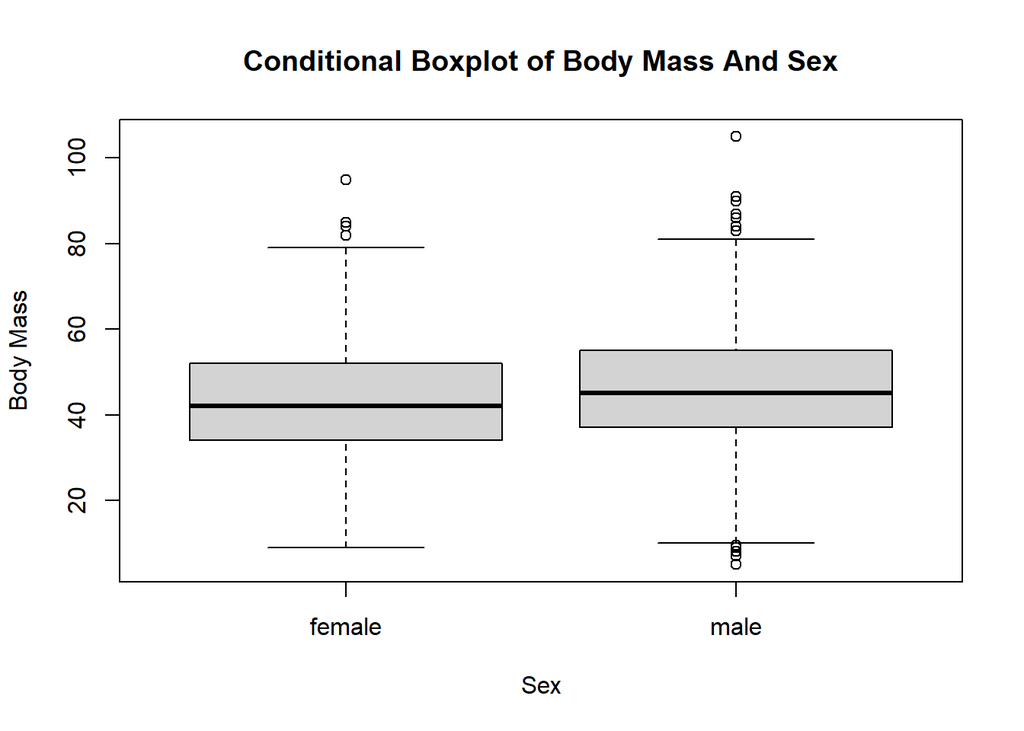

```r
boxplot(body_mass~sex, data=delomys,
        main = "Conditional Boxplot of Body Mass And Sex",
        xlab = "Sex",
        ylab = "Body Mass"
          )
```

Body mass, conditioned on both species and sex

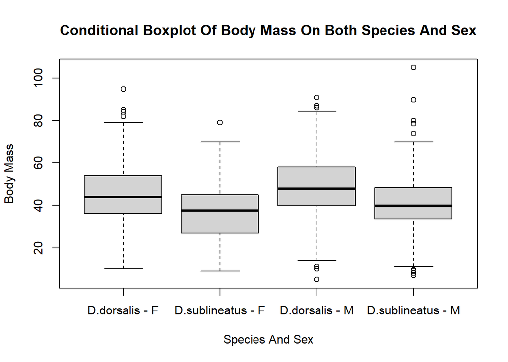

```r
boxplot(body_mass~binomial * sex, data=delomys,
        main = "Conditional Boxplot Of Body Mass On Both Species And Sex",
        xlab = "Species And Sex",
        ylab = "Body Mass",
        names = c("D.dorsalis - F", "D.sublineatus - F", "D.dorsalis - M", "D.sublineatus - M")
          )
```

### Quesitons

Question 1:

- Qualitatively describe the relationship between body mass and length. Does the relationship seem linear, curved, nonexistent?

  The relationship between body mass and body length is clustered but has a generally linear relationship. The linear trend in the graph shows that when body length increases, body mass generally increases as well. The points that are farther away from the main cluster trend represent statistical anomalies, for example the delomys points at the top of the boxplot show above average body length for their weight. I would describe these rodents as long and skinny.

Question 2:

- Qualitatively describe the shapes of the histograms. Do the data appear normally-distributed? Explain why or why not.
  - Body Mass Histogram:
    - The body mass histogram appears to be normally distributed which shows a bell pattern. There does seem to be a slight skew to the right. There is a clear minimum range, median range, and max range. As body mass increase, there are less frequency occurances.
  - Body Length Histogram:
    - The body length histogram shows that most of the occurances are measured as between 100 and 140 (there are no units listed). The distribution of the body length data is not normally distributed. The data shows that this species grows to a consistant legnth range with little distribution. Therefore I would describe this distribution as not varying.

Question 3:

- Using both the histograms and normality tests, do you think the (unconditioned) body masses and body length are normally-distributed?

  The shapiro normality tests showed p-vlaues of 4.33e-05 (body mass) and 2.2e-16 (body length). Since both of these p-values are less than 0.05, the test indicates that the normality of the distribution is not normal.

Question 4:

- Contrast your visual assessment of normality to the results of the numerical normality tests. Examine the conditional boxplots. Describe any graphical evidence you see for body mass differences based on species and/or sex.

## Model Building

### Model 1

Simple Linear Regression Body Length ~ Body Mass

```r
fit1 = lm(body_length ~ body_mass, data= delomys)
coef(fit1)
```

```
## (Intercept)   body_mass
##  76.1246565   0.8754988
```

### Model 2

1-way ANOVA Body Mass ~ Sex

```r
fit2 = lm(body_mass ~ sex, data=delomys)
summary(fit2)
```

```
##
## Call:
## lm(formula = body_mass ~ sex, data = delomys)
##
## Residuals:
##     Min      1Q  Median      3Q     Max
## -40.496  -8.711  -0.496   9.504  59.504
##
## Coefficients:
##             Estimate Std. Error t value Pr(>|t|)
## (Intercept)  42.7115     0.5289  80.756  < 2e-16 ***
## sexmale       2.7841     0.7456   3.734 0.000195 ***
## ---
## Signif. codes:  0 '***' 0.001 '**' 0.01 '*' 0.05 '.' 0.1 ' ' 1
##
## Residual standard error: 14.82 on 1578 degrees of freedom
##   (5 observations deleted due to missingness)
## Multiple R-squared:  0.008758,   Adjusted R-squared:  0.00813
## F-statistic: 13.94 on 1 and 1578 DF,  p-value: 0.0001951
```

```r
anova(fit2)
```

```
## Analysis of Variance Table
##
## Response: body_mass
##             Df Sum Sq Mean Sq F value    Pr(>F)
## sex          1   3062 3061.68  13.943 0.0001951 ***
## Residuals 1578 346507  219.59
## ---
## Signif. codes:  0 '***' 0.001 '**' 0.01 '*' 0.05 '.' 0.1 ' ' 1
```

### Model 3

1-Way ANOVA Body_Mass ~ Binomial

```r
fit3 = lm(body_mass~binomial, data = delomys)
summary(fit3)
```

```
##
## Call:
## lm(formula = body_mass ~ binomial, data = delomys)
##
## Residuals:
##     Min      1Q  Median      3Q     Max
## -41.752  -9.069  -0.069   9.248  65.931
##
## Coefficients:
##                             Estimate Std. Error t value Pr(>|t|)
## (Intercept)                  46.7524     0.4500   103.9   <2e-16 ***
## binomialDelomys sublineatus  -7.6831     0.7605   -10.1   <2e-16 ***
## ---
## Signif. codes:  0 '***' 0.001 '**' 0.01 '*' 0.05 '.' 0.1 ' ' 1
##
## Residual standard error: 14.44 on 1583 degrees of freedom
## Multiple R-squared:  0.06058,    Adjusted R-squared:  0.05998
## F-statistic: 102.1 on 1 and 1583 DF,  p-value: < 2.2e-16
```

```r
anova(fit3)
```

```
## Analysis of Variance Table
##
## Response: body_mass
##             Df Sum Sq Mean Sq F value    Pr(>F)
## binomial     1  21290 21289.7  102.08 < 2.2e-16 ***
## Residuals 1583 330164   208.6
## ---
## Signif. codes:  0 '***' 0.001 '**' 0.01 '*' 0.05 '.' 0.1 ' ' 1
```

### Model 4

2-Way Additive ANOVA Body Mass ~ Sex + Binomial

```r
fit4 = lm(body_mass~sex + binomial, data = delomys)
summary(fit4)
```

```
##
## Call:
## lm(formula = body_mass ~ sex + binomial, data = delomys)
##
## Residuals:
##     Min      1Q  Median      3Q     Max
## -43.866  -8.866  -0.672   8.930  64.328
##
## Coefficients:
##                             Estimate Std. Error t value Pr(>|t|)
## (Intercept)                  45.0704     0.5556  81.114  < 2e-16 ***
## sexmale                       3.7954     0.7260   5.228 1.94e-07 ***
## binomialDelomys sublineatus  -8.1935     0.7610 -10.767  < 2e-16 ***
## ---
## Signif. codes:  0 '***' 0.001 '**' 0.01 '*' 0.05 '.' 0.1 ' ' 1
##
## Residual standard error: 14.31 on 1577 degrees of freedom
##   (5 observations deleted due to missingness)
## Multiple R-squared:  0.07663,    Adjusted R-squared:  0.07546
## F-statistic: 65.44 on 2 and 1577 DF,  p-value: < 2.2e-16
```

```r
anova(fit4)
```

```
## Analysis of Variance Table
##
## Response: body_mass
##             Df Sum Sq Mean Sq F value    Pr(>F)
## sex          1   3062  3061.7  14.958 0.0001144 ***
## binomial     1  23727 23727.1 115.923 < 2.2e-16 ***
## Residuals 1577 322780   204.7
## ---
## Signif. codes:  0 '***' 0.001 '**' 0.01 '*' 0.05 '.' 0.1 ' ' 1
```

### Model 5

2-Way Factorial ANOVA Body Mass ~ Sex * Binomial

```r
fit5 = lm(body_mass~sex * binomial, data = delomys)
summary(fit5)
```

```
##
## Call:
## lm(formula = body_mass ~ sex * binomial, data = delomys)
##
## Residuals:
##     Min      1Q  Median      3Q     Max
## -43.884  -8.884  -0.647   8.945  64.353
##
## Coefficients:
##                                     Estimate Std. Error t value Pr(>|t|)
## (Intercept)                         45.05546    0.60530  74.435  < 2e-16 ***
## sexmale                              3.82809    0.89667   4.269 2.08e-05 ***
## binomialDelomys sublineatus         -8.14174    1.12810  -7.217 8.22e-13 ***
## sexmale:binomialDelomys sublineatus -0.09502    1.52859  -0.062     0.95
## ---
## Signif. codes:  0 '***' 0.001 '**' 0.01 '*' 0.05 '.' 0.1 ' ' 1
##
## Residual standard error: 14.31 on 1576 degrees of freedom
##   (5 observations deleted due to missingness)
## Multiple R-squared:  0.07664,    Adjusted R-squared:  0.07488
## F-statistic:  43.6 on 3 and 1576 DF,  p-value: < 2.2e-16
```

```r
anova(fit5)
```

```
## Analysis of Variance Table
##
## Response: body_mass
##                Df Sum Sq Mean Sq  F value    Pr(>F)
## sex             1   3062  3061.7  14.9489  0.000115 ***
## binomial        1  23727 23727.1 115.8500 < 2.2e-16 ***
## sex:binomial    1      1     0.8   0.0039  0.950442
## Residuals    1576 322779   204.8
## ---
## Signif. codes:  0 '***' 0.001 '**' 0.01 '*' 0.05 '.' 0.1 ' ' 1
```